# Data Mining Lab 3

Gregroy Asamoah, David Churchman, Ann Nelson

July 28, 2018

# Business Understanding

With frequent news of school shootings and police-related violence, there is widespread interest in studying data associated with gun violence incidents. A data set recording all U.S. gun violence events between January 2013 and March 2018, is available for study on [kaggle.com](https://www.kaggle.com/jameslko/gun-violence-data). This data was mined from the Gun Violence Archive using a Python script by James Ko and posted publicly on Kaggle for open investigation. The Gun Violence Archive collects its data by utilizing, “automated queries, manual research through over 2,000 media sources, aggregates, police blotters, police media outlets and other sources daily. Each incident is verified by both initial researchers and secondary validation processes.”  
This dataset contains a record of more than 230,000 U.S. gun-related incidents, providing detailed information about the event location both geographic and descriptive, number of participants, number killed or injured, etc. and data related to the shooters and victims (such as age, relationships, count, gender). The dataset also includes a link to the news source from which the data record was obtained. The dataset was created to help close an information-availability gap and make data related to gun violence readily available for analysis, providing opportunity for identifying correlations, developing predictive trend models, and influencing decision-making.  
In the previous two labs, we did exploratory analysis of the data and created algorithms aimed at predicting the level of fatality of a given shooting incident based on the dataset. We used a variety of classification and regression techniques, but in the end, our predictions were only a small amount greater than chance. Though this data set is extensive, it is still limited in quality, and may not provide enough information or reliable enough information to be highly predictive.  
In this lab, rather than attempting predictions, we will look for associations in the dataset, and attempt to create and interpret rules of association which can explain broad trends in gun violence incidents from the last five years. These rules of association could potentially help law enforcement, journalists and researchers better understand patterns found in shooting incidents.

# Data understanding 1

To begin, we downloaded the data as a csv and loaded it into a dataframe. The data includes 29 variables. We focused extensively on the number killed and injured in our predictive models, but will drop these variables for this analysis in order to focus on other categorical measures. Similary, nine variables of have to do with the location of the incident. We did find in previous labs that the state the shooting occurred appeared to have some predictive power, but for the sake of speed and reducing dimensionality, we will drop all location variables. We also saw seasonal and day-of-the-week effects, but in this case, we will drop the date variables. Additionally, we will drop the three variables having to do with links to sources for more information about the shooting, as well as the variable “notes,” which are unstructured qualitative descriptions of each incident and the participants names. There is both ‘participant_age’ and ‘age_group’, so we will drop the continuous ‘age’ to use ‘age_group’.  
In addition to shooting incidents, the dataset includes a number of gun-seizures from crime scenes and airports that involved large numbers of guns but no victims or shootings, so these incidents were removed from the dataset.  
This leaves 9 variables for analysis:

- incident_id: a unique identifier for each incident.
- gun_stolen: Key-value pairs of whether each gun in the incident was stolen
- gun_type: Key-value pairs, using the same key as ‘gun_stolen’ describing the type of gun used
- incident_characteristics: a category describing the incident, i.e. “Drive-by”, “Armed robbery”, etc.
- participants: five variables contain key-value pairs describing the different participants in the incident:
  - age_group
  - gender
  - relationship, i.e. “family”, “significant other”, etc.
  - status, i.e. “killed”, “unharmed”, “arrested”, etc.
  - type: “victim” or “suspect”

```r
#load <- read.csv("gunViolence.csv", header=TRUE)
df <- subset(load, select=-c(incident_url,notes,location_description,participant_name,
                            n_killed, n_injured, n_guns_involved,
                           state_senate_district, sources, state,participant_age, date,
                           longitude,latitude,congressional_district,state_house_district,
                           incident_url_fields_missing,source_url,address,city_or_county))

df <- df[!grepl("Non-Shooting Incident", df$incident_characteristics),]
df <- df[!grepl("Gun buy back action", df$incident_characteristics),]
df <- df[!grepl("Possession \\(gun\\(s\\) found during commission of other crimes\\)",
                df$incident_characteristics),]

library(knitr)
kable(summary(df[,2:ncol(df)]))
```

|  | gun_stolen | gun_type | incident_characteristics | participant_age_group | participant_gender | participant_relationship | participant_status | participant_type |
| --- | --- | --- | --- | --- | --- | --- | --- | --- |
|  | 0::Unknown :90384 | :86617 | Shot - Wounded/Injured :47541 | 0::Adult 18+ :69024 | 0::Male :67211 | :169969 | 0::Injured :41003 | 0::Victim :56647 |
|  | :86653 | 0::Unknown :78511 | Shot - Dead (murder, accidental, suicide) :23019 | 0::Adult 18+\|\|1::Adult 18+ :40267 | 0::Male\|\|1::Male :35974 | 1::Family : 2405 | 0::Killed :20837 | 0::Victim\|\|1::Subject-Suspect :44698 |
|  | 0::Unknown\|\|1::Unknown : 2783 | 0::Handgun : 5713 | Shots Fired - No Injuries :15690 | :31551 | :27186 | 1::Significant others - current or former: 2350 | :19792 | 0::Subject-Suspect :18288 |
|  | 0::Not-stolen : 955 | 0::9mm : 1542 | Shot - Wounded/Injured\|\|Drive-by (car to street, car to car) : 5121 | 0::Adult 18+\|\|1::Adult 18+\|\|2::Adult 18+ :10864 | 0::Male\|\|1::Male\|\|2::Male: 9646 | 1::Armed Robbery : 1493 | 0::Injured\|\|1::Unharmed :11721 | :17881 |
|  | 0::Stolen : 797 | 0::Unknown\|\|1::Unknown: 1317 | Armed robbery with injury/death and/or evidence of DGU found : 3438 | 0::Teen 12-17 : 5221 | 0::Female\|\|1::Male : 8536 | 1::Armed Robbery\|\|2::Armed Robbery : 864 | 0::Killed\|\|1::Unharmed, Arrested : 7377 | 0::Victim\|\|1::Subject-Suspect\|\|2::Subject-Suspect: 9073 |
|  | 0::Unknown\|\|1::Unknown\|\|2::Unknown: 435 | 0::Shotgun : 1201 | Shot - Wounded/Injured\|\|Shot - Dead (murder, accidental, suicide): 3220 | 0::Adult 18+\|\|1::Adult 18+\|\|2::Adult 18+\|\|3::Adult 18+: 3785 | 0::Female : 6330 | 1::Friends : 819 | 0::Injured\|\|1::Unharmed, Arrested: 6617 | 0::Victim\|\|1::Victim : 8701 |
|  | (Other) : 915 | (Other) : 8021 | (Other) :84893 | (Other) :22210 | (Other) :28039 | (Other) : 5022 | (Other) :75575 | (Other) :27634 |

The summary table above shows high frequency examples from each of these remaining variables. There are 182922 total incidents left after cleaning. Of the variables left for analysis, the most complete is “incident_characteristics.” The key-value pairs describing guns and the participants are all missing tens of thousands of values, which made them problematic when we were creating prediction models, however association rules are designed around very sparse datasets like market-basket analysis, so it should be robust to these missing values. The structure of the key-value pairs will require further formatting before analysis can be completed.

# Data understanding 2

One key feature of the data is “incident_characteristics”, which contains categorical descriptors. Because of the large number of unique descriptors, we did not include this variable in previous labs, but using the tools of creating association rules gives several ways to help give better insight into this variable, which is essentially a short summary of each incident. First, we can transform the incidents into transactional data format and look at a brief summary:

```r
# Create dfInc for initial Association Rules analysis on just "Incident Characterics"
dfInc <-  df[c('incident_id','incident_characteristics')]

# Reshape dfInc into long format using tidyr in order to get it into transaction format for arules

dfIncLong <- dfInc %>%  # Since the separator || is an operator, need \\ as escape
  separate_rows(incident_characteristics, sep="\\|\\|")

# Change into transaction data for arules

transInc <- as(split(dfIncLong[,'incident_characteristics'],dfIncLong[,'incident_id']),
               "transactions")
#inspect(head(transInc))
summary(transInc)
```

```
## transactions as itemMatrix in sparse format with
##  182922 rows (elements/itemsets/transactions) and
##  504 columns (items) and a density of 0.003980554
##
## most frequent items:
##                                       Shot - Wounded/Injured
##                                                        89019
##                    Shot - Dead (murder, accidental, suicide)
##                                                        50946
##                                    Shots Fired - No Injuries
##                                                        32388
## Armed robbery with injury/death and/or evidence of DGU found
##                                                        16265
##                                    Officer Involved Incident
##                                                        13032
##                                                      (Other)
##                                                       165328
##
## element (itemset/transaction) length distribution:
## sizes
##     1     2     3     4     5     6     7     8     9    10    11    12
## 98013 40249 19390 11176  6389  3777  2052   983   478   246    86    51
##    13    14    16    18
##    20     8     3     1
##
##    Min. 1st Qu.  Median    Mean 3rd Qu.    Max.
##   1.000   1.000   1.000   2.006   2.000  18.000
##
## includes extended item information - examples:
##                        labels
## 1
## 2         Accidental Shooting
## 3 Accidental Shooting - Death
##
## includes extended transaction information - examples:
##   transactionID
## 1         92114
## 2         92117
## 3         92119
```

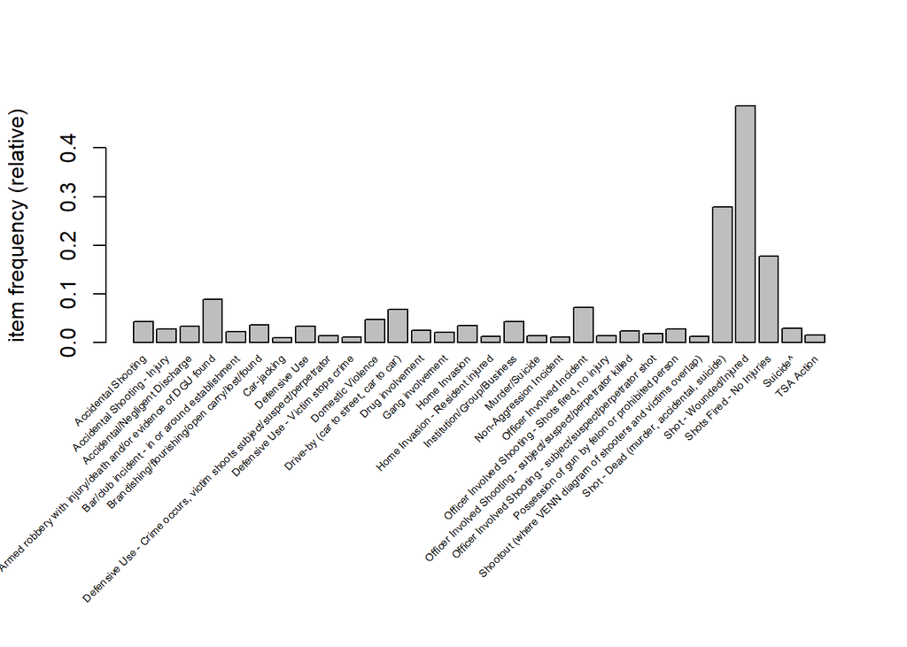

There are 504 total descriptors, so what might give better insight into this dataset is which tend to appear together in incidents, which may also reveal redundant descriptors. To get a broad array of rules, we will set the minimum support and confidence relatively low at 0.01 and 0.1 respectively.

```r
rulesInc <- apriori(transInc, parameter = list(support=0.01, confidence=.1))
```

```
## Apriori
##
## Parameter specification:
##  confidence minval smax arem  aval originalSupport maxtime support minlen
##         0.1    0.1    1 none FALSE            TRUE       5    0.01      1
##  maxlen target   ext
##      10  rules FALSE
##
## Algorithmic control:
##  filter tree heap memopt load sort verbose
##     0.1 TRUE TRUE  FALSE TRUE    2    TRUE
##
## Absolute minimum support count: 1829
##
## set item appearances ...[0 item(s)] done [0.00s].
## set transactions ...[504 item(s), 182922 transaction(s)] done [0.57s].
## sorting and recoding items ... [30 item(s)] done [0.01s].
## creating transaction tree ... done [0.14s].
## checking subsets of size 1 2 3 4 done [1.84s].
## writing ... [92 rule(s)] done [0.00s].
## creating S4 object  ... done [0.01s].
```

```r
inspect(head(rulesInc, n=10), by="confidence")
```

```
##      lhs                                                     rhs                                            support confidence      lift count
## [1]  {}                                                   => {Shots Fired - No Injuries}                 0.17705907  0.1770591  1.000000 32388
## [2]  {}                                                   => {Shot - Dead (murder, accidental, suicide)} 0.27851215  0.2785122  1.000000 50946
## [3]  {}                                                   => {Shot - Wounded/Injured}                    0.48665005  0.4866500  1.000000 89019
## [4]  {Home Invasion - Resident injured}                   => {Home Invasion}                             0.01185751  1.0000000 29.053685  2169
## [5]  {Home Invasion}                                      => {Home Invasion - Resident injured}          0.01185751  0.3445044 29.053685  2169
## [6]  {Home Invasion - Resident injured}                   => {Shot - Wounded/Injured}                    0.01005893  0.8483172  1.743177  1840
## [7]  {Murder/Suicide}                                     => {Suicide^}                                  0.01245886  0.9452509 33.418475  2279
## [8]  {Suicide^}                                           => {Murder/Suicide}                            0.01245886  0.4404716 33.418475  2279
## [9]  {Murder/Suicide}                                     => {Shot - Dead (murder, accidental, suicide)} 0.01303834  0.9892161  3.551788  2385
## [10] {Officer Involved Shooting - Shots fired, no injury} => {Officer Involved Incident}                 0.01345382  1.0000000 14.036372  2461
```

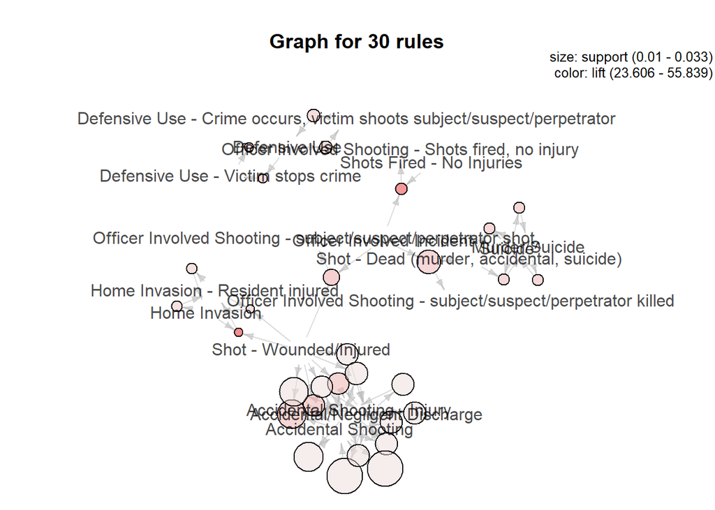

In addition to the home invasion, murder suicide and officer involved shooting groups we saw in the top 10 rules, we can see descriptors around accidental shootings and defensive shootings as well. These five main clusters all most likely have very different attributes, and in future regression and classification, they could be disaggregated and explored individually.

# Modeling and Evaluation 1

Besides incideent characteristics, there were also a handful of key-value pairs around the participants in each incident that we only were able to make limited use of in the past labs. Before, we totaled the number of participants in each incident of particular genders and age groups, but did not examine the relationships between participants nor did we disaggregate analysis by type of participant: victim or suspect. The table below gives a sense of the difficulty of analyzing the participant variables: they are unsorted, have variable length, and some, like the relationship to the suspect, are sparse.

```r
head(df[c('incident_id','participant_age_group','participant_gender','participant_status',
          'participant_type','participant_relationship')],5)
```

```
##   incident_id
## 2      460726
## 3      478855
## 4      478925
## 5      478959
## 6      478948
##                                                                participant_age_group
## 2                             0::Adult 18+||1::Adult 18+||2::Adult 18+||3::Adult 18+
## 3               0::Adult 18+||1::Adult 18+||2::Adult 18+||3::Adult 18+||4::Adult 18+
## 4                             0::Adult 18+||1::Adult 18+||2::Adult 18+||3::Adult 18+
## 5                            0::Adult 18+||1::Adult 18+||2::Teen 12-17||3::Adult 18+
## 6 0::Adult 18+||1::Adult 18+||2::Adult 18+||3::Adult 18+||4::Adult 18+||5::Adult 18+
##                                             participant_gender
## 2                                                      0::Male
## 3                  0::Male||1::Male||2::Male||3::Male||4::Male
```

[output cut: 21 more lines]

In this section, we will attempt to develop association rules that can give better insight into the participants of gun violence incidents in the Gun Violence Archive. First, we must prepare the data to be more transactional. In this case, each transaction will be a single participant in a single incident. The following code splits the key-value pairs into a long data format and merges all the data on the participant number and incident ID.

```r
library(tidyr)
### Reformat Participant Information for ARules Investigation###

#Age Group
dfPartAgeGroup <-  df[c('incident_id','participant_age_group')]

dfLongTemp <- dfPartAgeGroup %>% separate_rows(2, sep="\\|\\|")
dfLongTemp <- dfLongTemp[which(dfLongTemp[,2] != ''),]

dfPartAgeGroup <- suppressWarnings(separate(dfLongTemp,participant_age_group, into=c(
                    "part","age_group"), sep = "::", remove = TRUE, convert = TRUE))

#Gender
dfPartGender <-  df[c('incident_id','participant_gender')]

dfLongTemp <- dfPartGender %>% separate_rows(2, sep="\\|\\|")
dfLongTemp <- dfLongTemp[which(dfLongTemp[,2] != ''),]

dfPartGender <- suppressWarnings(separate(dfLongTemp,participant_gender, into=c("part","gender"),
                           sep = "::", remove = TRUE, convert = TRUE))

#Relationship
dfPartRelationship <-  df[c('incident_id','participant_relationship')]

dfLongTemp <- dfPartRelationship %>% separate_rows(2, sep="\\|\\|")
dfLongTemp <- dfLongTemp[which(dfLongTemp[,2] != ''),]

dfPartRelationship <- suppressWarnings(separate(dfLongTemp,participant_relationship, into=c("part","relationship"),
                         sep = "::", remove = TRUE, convert = TRUE))

#Status: Killed, Injured, Arrested, Unharmed
dfPartStatus <-  df[c('incident_id','participant_status')]

dfLongTemp <- dfPartStatus %>% separate_rows(2, sep="\\|\\|")
dfLongTemp <- dfLongTemp[which(dfLongTemp[,2] != ''),]

dfPartStatus <- suppressWarnings(separate(dfLongTemp,participant_status, into=c("part","status"),
                               sep = "::", remove = TRUE, convert = TRUE))

#Type: Suspect or Victim
dfPartType <-  df[c('incident_id','participant_type')]

dfLongTemp <- dfPartType %>% separate_rows(2, sep="\\|\\|")
dfLongTemp <- dfLongTemp[which(dfLongTemp[,2] != ''),]

dfPartType <- suppressWarnings(separate(dfLongTemp,participant_type, into=c("part","type"),
                         sep = "::", remove = TRUE, convert = TRUE))

#Merge all the participant variables
dfPart <- merge(dfPartType, dfPartStatus, by=c("incident_id","part"), all=TRUE)
dfPart <- merge(dfPart, dfPartAgeGroup, by=c("incident_id","part"), all=TRUE)
dfPart <- merge(dfPart, dfPartGender, by=c("incident_id","part"), all=TRUE)
dfPart <- merge(dfPart, dfPartRelationship, by=c("incident_id","part"), all=TRUE)
head(dfPart)
```

```
##   incident_id part            type             status age_group gender
## 1       92114    0          Victim            Injured Adult 18+   Male
## 2       92117    0          Victim            Injured Adult 18+   Male
## 3       92117    1 Subject-Suspect Unharmed, Arrested Adult 18+   Male
## 4       92119    0          Victim            Injured Adult 18+   Male
## 5       92122    0          Victim           Unharmed      <NA>   <NA>
## 6       92122    1 Subject-Suspect               <NA>      <NA>   <NA>
##   relationship
## 1         <NA>
## 2         <NA>
## 3      Friends
## 4         <NA>
## 5         <NA>
## 6         <NA>
```

This dataframe contains both suspects and victims. Both may yield interesting analyses, but for our analysis, we will focus on the suspects involved in gun violence incidents.

```r
dfSuspects <- dfPart[which(dfPart$type == "Subject-Suspect"),]
dfSuspects <- dfSuspects[order(dfSuspects$incident_id,dfSuspects$part),]
dfSuspects <- data.frame(unclass(dfSuspects))
```

We will be using the “arules” package in R to derive our association rules, which requires the data be in “transactional” form.

```r
library(arules)
suspectTrans <- as(dfSuspects[,4:ncol(dfSuspects)], "transactions")
summary(suspectTrans)
```

```
## transactions as itemMatrix in sparse format with
##  126660 rows (elements/itemsets/transactions) and
##  30 columns (items) and a density of 0.09402469
##
## most frequent items:
##               gender=Male       age_group=Adult 18+
##                    108528                     96610
##           status=Unharmed status=Unharmed, Arrested
##                     58093                     41813
##             status=Killed                   (Other)
##                      8634                     43597
##
## element (itemset/transaction) length distribution:
## sizes
##     0     1     2     3     4
##  1879  6622 17414 87155 13590
##
##    Min. 1st Qu.  Median    Mean 3rd Qu.    Max.
##   0.000   3.000   3.000   2.821   3.000   4.000
##
## includes extended item information - examples:
##                     labels variables            levels
## 1          status=Arrested    status          Arrested
## 2           status=Injured    status           Injured
## 3 status=Injured, Arrested    status Injured, Arrested
##
## includes extended transaction information - examples:
##   transactionID
## 1             1
## 2             2
## 3             3
```

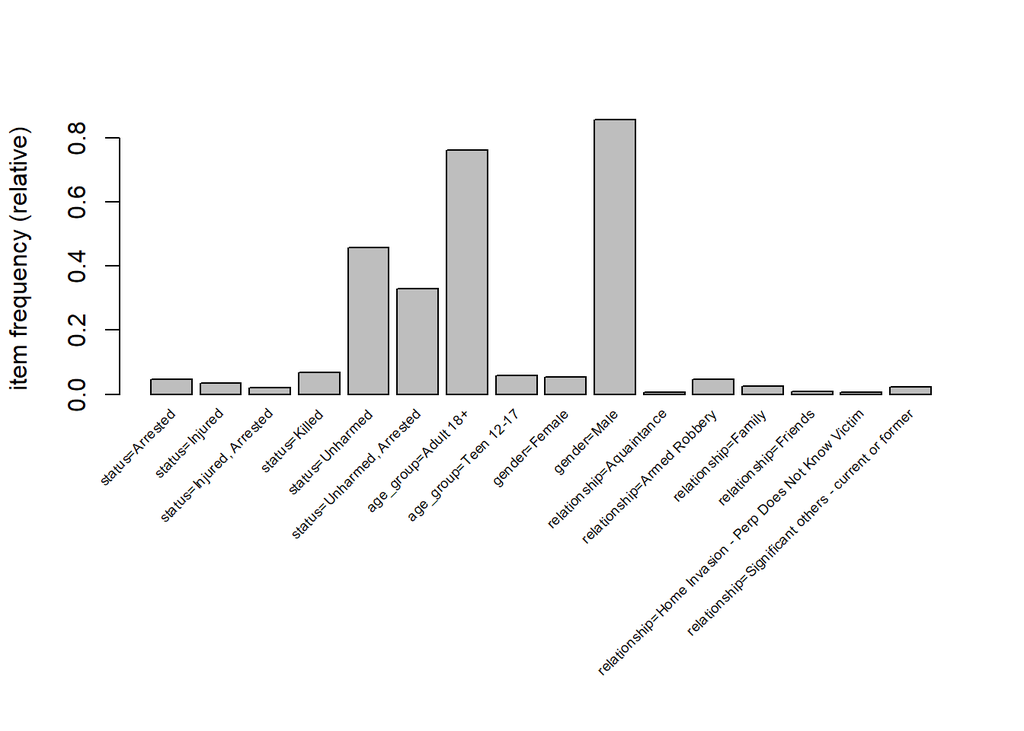

Next, we will see if there are any associations that bring more insights into the suspects of shoting besides those seen in their relative frequencies.

```r
suspectRules <- apriori(suspectTrans,
                        parameter = list(support = 0.01, confidence = 0.01))
```

```
## Apriori
##
## Parameter specification:
##  confidence minval smax arem  aval originalSupport maxtime support minlen
##        0.01    0.1    1 none FALSE            TRUE       5    0.01      1
##  maxlen target   ext
##      10  rules FALSE
##
## Algorithmic control:
##  filter tree heap memopt load sort verbose
##     0.1 TRUE TRUE  FALSE TRUE    2    TRUE
##
## Absolute minimum support count: 1266
##
## set item appearances ...[0 item(s)] done [0.00s].
## set transactions ...[30 item(s), 126660 transaction(s)] done [0.02s].
## sorting and recoding items ... [13 item(s)] done [0.00s].
## creating transaction tree ... done [0.04s].
## checking subsets of size 1 2 3 4 done [0.06s].
## writing ... [136 rule(s)] done [0.00s].
## creating S4 object  ... done [0.01s].
```

```r
summary(suspectRules)
```

```
## set of 136 rules
##
## rule length distribution (lhs + rhs):sizes
##  1  2  3  4
## 13 58 57  8
##
##    Min. 1st Qu.  Median    Mean 3rd Qu.    Max.
##   1.000   2.000   2.000   2.441   3.000   4.000
##
## summary of quality measures:
##     support          confidence           lift            count
##  Min.   :0.01018   Min.   :0.01987   Min.   :0.6454   Min.   :  1290
##  1st Qu.:0.01562   1st Qu.:0.04791   1st Qu.:0.9922   1st Qu.:  1979
##  Median :0.02401   Median :0.45828   Median :1.0534   Median :  3042
##  Mean   :0.08063   Mean   :0.45623   Mean   :1.0815   Mean   : 10213
##  3rd Qu.:0.04750   3rd Qu.:0.85333   3rd Qu.:1.1519   3rd Qu.:  6016
##  Max.   :0.85685   Max.   :0.97649   Max.   :1.6213   Max.   :108528
##
## mining info:
##          data ntransactions support confidence
##  suspectTrans        126660    0.01       0.01
```

There were enough associations between variables to create 136 rules for analysis. Also of note is the very fast performance of creating these rules; well under one second total. Most of these rules, involved associatinng 2 or 3 variables, though there some with 1 and 4 variables included.

```r
inspect(head(suspectRules, n=10,by="confidence"))
```

```
##      lhs                                                      rhs                      support confidence     lift count
## [1]  {status=Unharmed, Arrested,
##       relationship=Significant others - current or former} => {age_group=Adult 18+} 0.01049266  0.9764879 1.280219  1329
## [2]  {gender=Male,
##       relationship=Significant others - current or former} => {age_group=Adult 18+} 0.01786673  0.9729149 1.275535  2263
## [3]  {relationship=Significant others - current or former} => {age_group=Adult 18+} 0.02226433  0.9694053 1.270933  2820
## [4]  {status=Killed,
##       gender=Male}                                         => {age_group=Adult 18+} 0.06106900  0.9558824 1.253204  7735
## [5]  {status=Injured, Arrested,
##       age_group=Adult 18+}                                 => {gender=Male}         0.01696668  0.9546868 1.114188  2149
## [6]  {status=Killed}                                       => {age_group=Adult 18+} 0.06488236  0.9518184 1.247876  8218
## [7]  {status=Injured, Arrested}                            => {gender=Male}         0.01874309  0.9431863 1.100766  2374
## [8]  {status=Killed,
##       age_group=Adult 18+}                                 => {gender=Male}         0.06106900  0.9412266 1.098479  7735
## [9]  {status=Unharmed,
##       age_group=Adult 18+,
##       relationship=Armed Robbery}                          => {gender=Male}         0.01466919  0.9388580 1.095715  1858
## [10] {status=Killed}                                       => {gender=Male}         0.06388757  0.9372249 1.093809  8092
```

Looking at the rules, we see the assignment to left and right hand sides is arbitrary, which muddies potential analysis. The most interesting attribute about the suspect is their status after the shooting, so to better tune the rules for analysis of suspect status, we will make the status the right hand side of the association rules.

```r
suspectRules <- apriori(suspectTrans,
                        parameter = list(support = 0.01, confidence = 0.01),
                        appearance = list(rhs=
                                           c('status=Unharmed, Arrested','status=Unharmed',
                                              'status=Injured','status=Killed',
                                              'status=Injured, Arrested','status=Killed, Unharmed',
                                              'status=Arrested','status=Killed, Arrested',
                                              'status=Injured, Unharmed',
                                              'status=Injured, Unharmed, Arrested',
                                              'status=Killed, Injured',
                                              'status=Killed, Unharmed, Arrested'))
                                          )
```

```
## Apriori
##
## Parameter specification:
##  confidence minval smax arem  aval originalSupport maxtime support minlen
##        0.01    0.1    1 none FALSE            TRUE       5    0.01      1
##  maxlen target   ext
##      10  rules FALSE
##
## Algorithmic control:
##  filter tree heap memopt load sort verbose
##     0.1 TRUE TRUE  FALSE TRUE    2    TRUE
##
## Absolute minimum support count: 1266
##
## set item appearances ...[12 item(s)] done [0.00s].
## set transactions ...[30 item(s), 126660 transaction(s)] done [0.02s].
## sorting and recoding items ... [13 item(s)] done [0.00s].
## creating transaction tree ... done [0.04s].
## checking subsets of size 1 2 3 4 done [0.00s].
## writing ... [44 rule(s)] done [0.00s].
## creating S4 object  ... done [0.01s].
```

```r
summary(suspectRules)
```

```
## set of 44 rules
##
## rule length distribution (lhs + rhs):sizes
##  1  2  3  4
##  6 20 16  2
##
##    Min. 1st Qu.  Median    Mean 3rd Qu.    Max.
##   1.000   2.000   2.000   2.318   3.000   4.000
##
## summary of quality measures:
##     support          confidence           lift            count
##  Min.   :0.01018   Min.   :0.01987   Min.   :0.6575   Min.   : 1290
##  1st Qu.:0.01550   1st Qu.:0.04766   1st Qu.:1.0000   1st Qu.: 1964
##  Median :0.02557   Median :0.33112   Median :1.0383   Median : 3239
##  Mean   :0.08087   Mean   :0.28019   Mean   :1.0956   Mean   :10243
##  3rd Qu.:0.06177   3rd Qu.:0.46095   3rd Qu.:1.1886   3rd Qu.: 7824
##  Max.   :0.45865   Max.   :0.53827   Max.   :1.6054   Max.   :58093
##
## mining info:
##          data ntransactions support confidence
##  suspectTrans        126660    0.01       0.01
```

# Modeling and Evaluation 3

First, we will look at a parallel coordinate plot, ordered to minimize crossings.

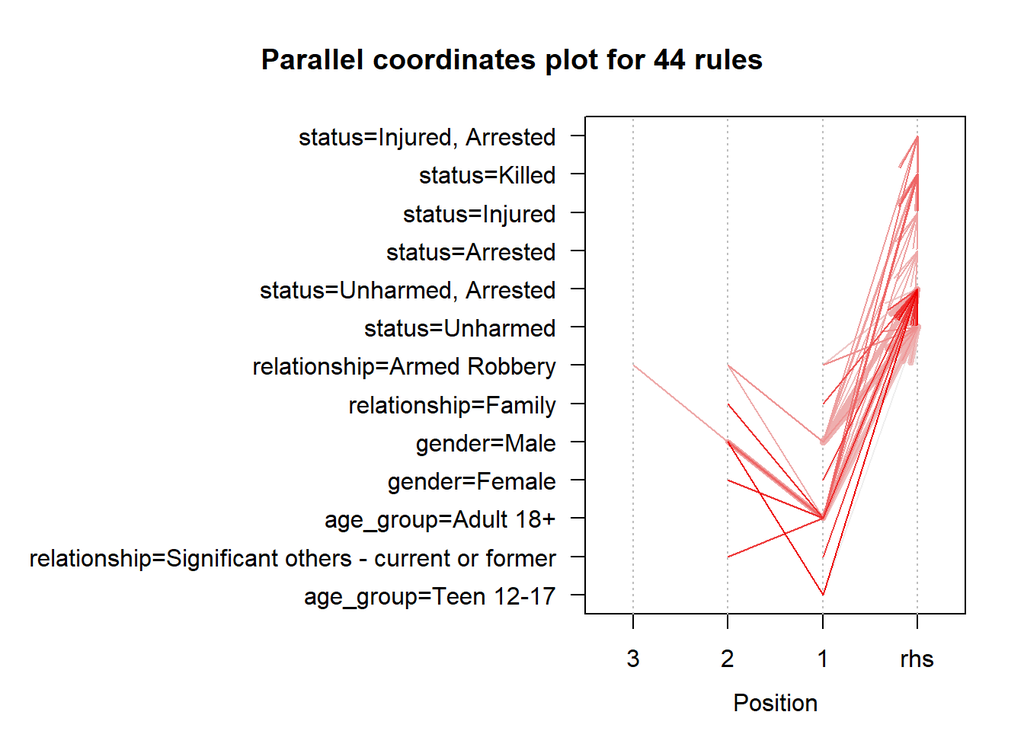

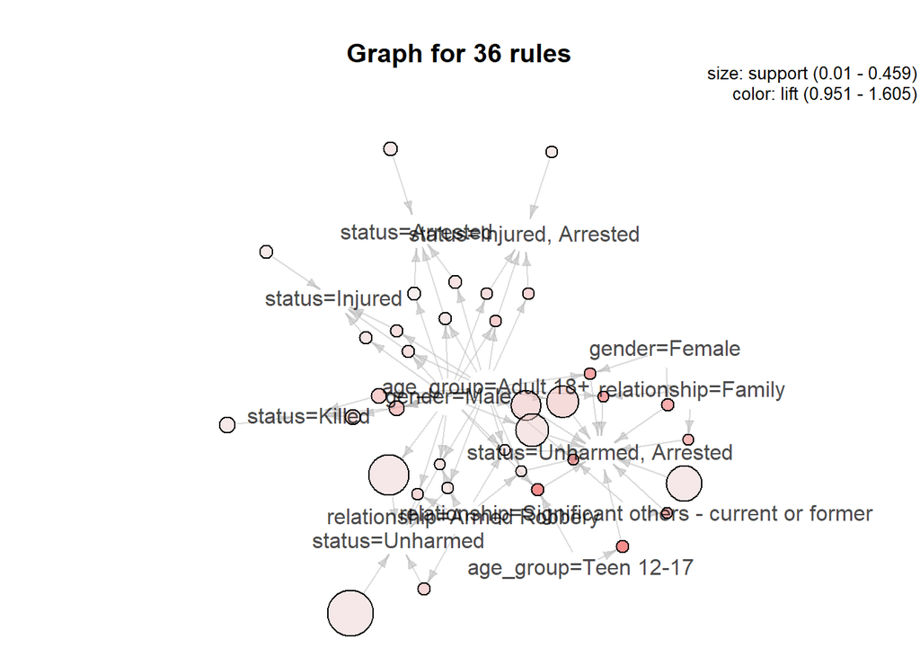

The graph plot reveals interesting relation, but both it and the parallel coordinates can be difficult to see all relations, so as a final visualization of all the rules, we will plot them as a matrix, with shading weighted by lift, and ordered by support.

```
## Itemsets in Antecedent (LHS)
##  [1] "{}"
##  [2] "{gender=Male}"
##  [3] "{age_group=Adult 18+}"
##  [4] "{age_group=Adult 18+,gender=Male}"
##  [5] "{age_group=Teen 12-17}"
##  [6] "{gender=Female}"
##  [7] "{age_group=Teen 12-17,gender=Male}"
##  [8] "{relationship=Armed Robbery}"
##  [9] "{age_group=Adult 18+,gender=Female}"
## [10] "{gender=Male,relationship=Armed Robbery}"
## [11] "{age_group=Adult 18+,relationship=Armed Robbery}"
## [12] "{age_group=Adult 18+,gender=Male,relationship=Armed Robbery}"
## [13] "{relationship=Family}"
## [14] "{relationship=Significant others - current or former}"
## [15] "{age_group=Adult 18+,relationship=Significant others - current or former}"
## [16] "{age_group=Adult 18+,relationship=Family}"
## Itemsets in Consequent (RHS)
## [1] "{status=Injured, Arrested}"  "{status=Injured}"
## [3] "{status=Arrested}"           "{status=Killed}"
## [5] "{status=Unharmed, Arrested}" "{status=Unharmed}"
```

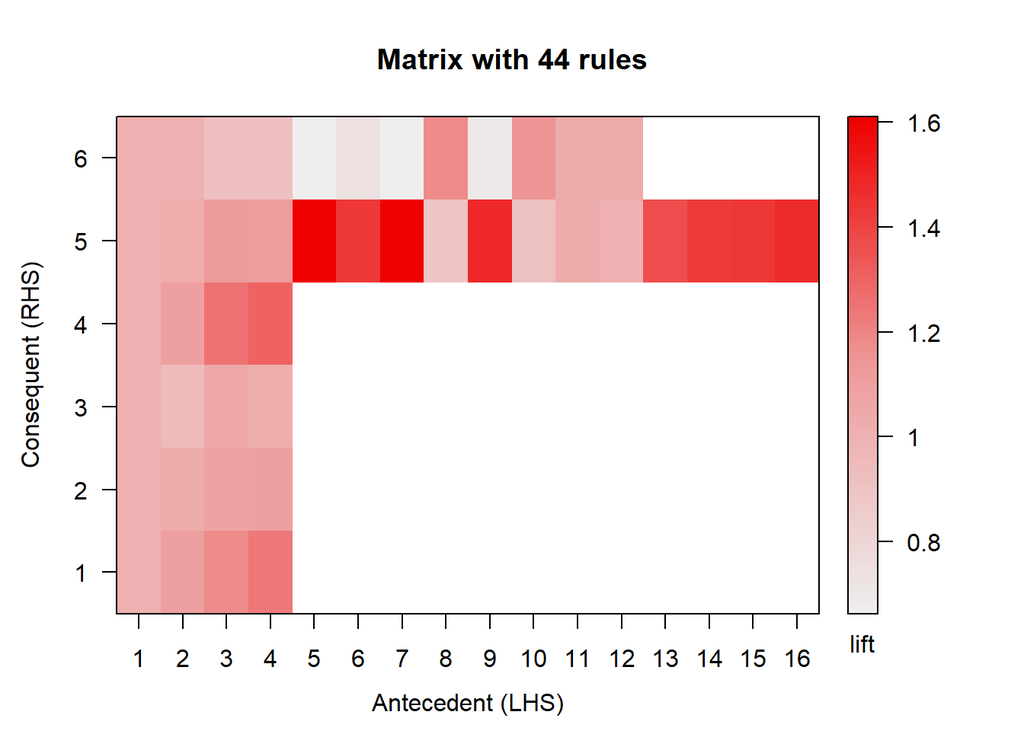

```r
plot(suspectRules, method="matrix", measure="lift", control=list(reorder='support/confidence'))
```

What the matrix makes clear that was harder to see in the other graphs is that only four of the antecedents have corresponding associations with the consequents. Those four are:

- No antecedent
- Male
- Adult
- Adult and male

All other antecendents, including teenaged, child, female, and relationships only had consequents of “Unharmed” or “Unharmed, arrested.” The consequents that adults, males, and adult males were associated with included these two, but also “killed”, “injured,” and “injured, arrested.” The darker shading indicates that adults and males are more likely to be associated with being and killed in shooting incidents, whereas teenagers, females, and the various other antecedents are more darkly shaded in the unharmed consequents. It is promising that the darkest band is the “unharmed, arrested,” which indicates law enforcement was able to capture the shooting suspect without injuring them in many of the shooting incidents.

# Modeling and Evaluation 2

For comparison, we can look at association rules for the victims in the datast using the same parameters. First, let us look at the relative frequency of variables for victims:

```
## transactions in sparse format with
##  172562 transactions (rows) and
##  18 items (columns)
```

```
## transactions as itemMatrix in sparse format with
##  172562 rows (elements/itemsets/transactions) and
##  18 columns (items) and a density of 0.151618
##
## most frequent items:
## age_group=Adult 18+         gender=Male      status=Injured
##              136359              125707              101815
##       status=Killed       gender=Female             (Other)
##               48563               26335               32164
##
## element (itemset/transaction) length distribution:
## sizes
##      0      1      2      3
##   3691   9184  17302 142385
##
##    Min. 1st Qu.  Median    Mean 3rd Qu.    Max.
##   0.000   3.000   3.000   2.729   3.000   3.000
##
## includes extended item information - examples:
##                     labels variables            levels
## 1          status=Arrested    status          Arrested
## 2           status=Injured    status           Injured
## 3 status=Injured, Arrested    status Injured, Arrested
##
## includes extended transaction information - examples:
##   transactionID
## 1             1
## 2             2
## 3             3
```

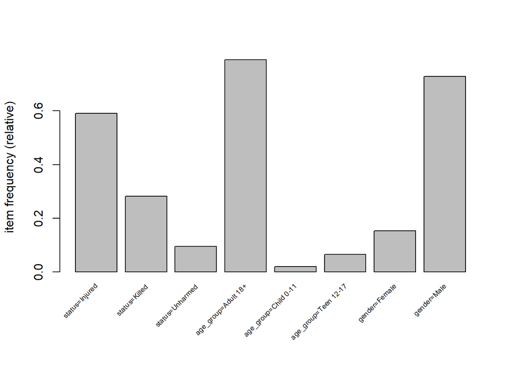

```
##  [1] Unharmed, Arrested          <NA>
##  [3] Unharmed                    Injured
##  [5] Killed                      Injured, Arrested
##  [7] Killed, Unharmed            Arrested
##  [9] Killed, Arrested            Injured, Unharmed
## [11] Injured, Unharmed, Arrested Killed, Injured
## [13] Killed, Unharmed, Arrested
## 12 Levels: Arrested Injured Injured, Arrested ... Unharmed, Arrested
```

```
## Apriori
##
## Parameter specification:
##  confidence minval smax arem  aval originalSupport maxtime support minlen
##        0.01    0.1    1 none FALSE            TRUE       5    0.01      1
##  maxlen target   ext
##      10  rules FALSE
##
## Algorithmic control:
##  filter tree heap memopt load sort verbose
##     0.1 TRUE TRUE  FALSE TRUE    2    TRUE
##
## Absolute minimum support count: 1725
##
## set item appearances ...[12 item(s)] done [0.00s].
## set transactions ...[18 item(s), 172562 transaction(s)] done [0.03s].
## sorting and recoding items ... [8 item(s)] done [0.00s].
## creating transaction tree ... done [0.06s].
## checking subsets of size 1 2 3 done [0.00s].
## writing ... [23 rule(s)] done [0.00s].
## creating S4 object  ... done [0.01s].
```

Like the suspect frequencies, adults and males are high outliers. Unlike the suspects, “injured” and “killed” are much higher relative to “unharmed.” This is unsurprising that victims of shootings are more likely to be injured or killed than the suspects in the shootings. Next, we will look at associations amongst the variables for victims.

```r
summary(victimRules)
```

```
## set of 23 rules
##
## rule length distribution (lhs + rhs):sizes
##  1  2  3
##  3 12  8
##
##    Min. 1st Qu.  Median    Mean 3rd Qu.    Max.
##   1.000   2.000   2.000   2.217   3.000   3.000
##
## summary of quality measures:
##     support          confidence          lift            count
##  Min.   :0.01053   Min.   :0.0720   Min.   :0.7637   Min.   :  1817
##  1st Qu.:0.03866   1st Qu.:0.1930   1st Qu.:0.8926   1st Qu.:  6671
##  Median :0.06413   Median :0.3211   Median :1.0000   Median : 11067
##  Mean   :0.15120   Mean   :0.3620   Mean   :1.0551   Mean   : 26091
##  3rd Qu.:0.24134   3rd Qu.:0.5514   3rd Qu.:1.1537   3rd Qu.: 41646
##  Max.   :0.59002   Max.   :0.7126   Max.   :1.6887   Max.   :101815
##
## mining info:
##         data ntransactions support confidence
##  victimTrans        172562    0.01       0.01
```

Using the same parameters we used before for suspects, we see 23 association rules. We are most interested in those with a lift greater than one, meaning a positive correlation between the antecedent and consequent and that we can tell the antecedent is more likely to occur with the consequent. There are only ten rules for victims for which this is true, so we will look at those directly:

```r
inspect(head(victimRules, n=10,by="lift"))
```

```
##      lhs                       rhs                  support confidence     lift count
## [1]  {age_group=Adult 18+,
##       gender=Female}        => {status=Unharmed} 0.02027098  0.1591881 1.688684  3498
## [2]  {gender=Female}        => {status=Unharmed} 0.02396820  0.1570534 1.666038  4136
## [3]  {age_group=Teen 12-17} => {status=Injured}  0.04661513  0.7125520 1.207675  8044
## [4]  {age_group=Teen 12-17,
##       gender=Male}          => {status=Injured}  0.03552346  0.7073621 1.198879  6130
## [5]  {age_group=Adult 18+,
##       gender=Male}          => {status=Killed}   0.20905530  0.3356907 1.192831 36075
## [6]  {age_group=Adult 18+,
##       gender=Female}        => {status=Killed}   0.04179367  0.3282061 1.166235  7212
## [7]  {age_group=Adult 18+}  => {status=Killed}   0.25375807  0.3211303 1.141093 43789
## [8]  {gender=Male}          => {status=Killed}   0.22892062  0.3142466 1.116633 39503
## [9]  {gender=Female}        => {status=Killed}   0.04672523  0.3061705 1.087935  8063
## [10] {gender=Male}          => {status=Injured}  0.43510738  0.5972858 1.012315 75083
```

These rules are drastically different than those we saw for suspects. The victims rules contain both teenagers and females for “unharmed,” “injured”" and “killed”" outcomes. Adults and males also appear, though they are much more likely to be injured or killed in the victim rules than in the suspect rules. The consequent of “arrested” is not included for victims, which makes sense, as they are the victims of the shootings and you would not expect them to be arrested.

# Modeling and Evaluation 4

By creating association rules on the characteristics of suspects in over 100,000 shootings in the Gun Violence Archive, we were able find some interesting associations amongst the variables available in the archive to describe the suspects and victims. Without association rule mining, this task would have been fairly arduous, as each shooting involved a variable number of suspects and victims, and the variables used to describe them were sparse. The association rules generated were interprettable and gave new insights into an area of the Gun Violence Archive that was opaque to us in previous labs. In addition to this, the computations involved were very efficient, executing in well under a second on a commercially available laptop. Before learning association rule mining, it would have been very difficult to do pairwise comparisons on the dozens of variables associated with participants in the shootings to see which had significant relationships.  
In our association rules, we saw that most shootings resulted in the suspect being unharmed or unharmed and arrested, as these variables were associated with both genders, adults and teenagers, and various relationships between the suspect and victims. We also saw that for all outcomes, suspects were most likely to be male and adult. On the other hand, in the victim rules, we saw that females and teenagers were more represented, though males and adults were still the most likely victims. We also saw that victims were much more likely to be killed or injured in shooting incidents than suspects.

# Deployment

The goal of this lab was to “use transaction data for mining assocation rules.” The Gun Violence Archive did not contain transaction data, but we were able to successfully transform variables around incident characteristics and the participants to create transaction-like data for association rule mining. We were able successfully mine interpretable rules for the incident characteristics, victims, and suspects involved in the shooting. Computationally, this was very quick to do.  
For these specific results, interested parties would be any people interested in better understanding gun violence in the United States, including law enforcement, legislators and activitists. More broadly, the method of transforming sparse and unbalanced data into transactional data for association rule mining could be of interest to anyone beginning a data analysis on a similar data set. Because of its relative speed and the fast interpretation of its results, it would be especially useful at the EDA stage of data analysis, when a large variety of vizualizations are desired to build intuition around the relationships in a large dataset. Previously, large numbers of correlation plots might be constructed, which only works for numerical data, but association rules creates a path for finding relationships amongst a variety of categorical variables.

# Exceptional Work

Another variable in our dataset that was previously difficult to make use of was a location description. In the following section, we use natural language processing techniques in Python to derive insights from the location description of different gun violence incidents:

[output not shown]

```python
#load Gun Violoence CSV
import pandas as pd
import numpy as np
import matplotlib.pyplot as plt
import seaborn as sns
import string
from pandas import Series, DataFrame
import re


df =  pd.read_csv("C:\\Users\\aln15\\Documents\\SMUHomeWork\\DataMining7331\\Project\\gunViolence.csv", parse_dates = ['date'])
df['isMass'] = df['n_killed'] >= 3
df['n_involved'] = df.n_killed + df.n_injured



df = df[df['incident_characteristics'].str.contains("Non-Shooting Incident") == False]
df = df[df['incident_characteristics'].str.contains("Gun buy back action") == False]
df['year'] = df['date'].dt.year
df = df[df.year != 2013] #discard 2013 data.  Prior EDA identified the change in the data collection method
df2018 = df[df.year == 2018] #use this dataframe to assess the algorithm assignment
df = df[df.year != 2018] #remove 2018 data from the assignmnet dataframe
```

```python
#only the location column
df = DataFrame(df)
dfloc = df.loc[:, ['location_description','n_involved']]

#only non-nulls
dfloc = dfloc.dropna(how='any',axis=0)
```

```python
#create variables for classification of location_description and clean values

#uppercase
dfloc['location'] = dfloc['location_description'].str.upper()

#get a specific row in the dataframe
#dfloc['index1'] = dfloc.index
#dfloc = dfloc[dfloc.index == 23]

#remove 's
dfloc['location'] = dfloc.location.str.replace("'S",'')
dfloc['location'] = dfloc.location.str.replace('"S','')
dfloc['location'] = dfloc.location.str.replace("’S",'')

#remove trailing 'S'
dfloc['location'] = np.where((dfloc.location.str[-1] == 'S'), dfloc['location'].astype(str).str[:-1], dfloc.location)


#remove punctionation from the location
dfloc['location'] = dfloc['location'].str.replace('[^A-Za-z\s]+', '')

# var = count of the number of words
dfloc['wordcount'] = dfloc['location_description'].str.split().str.len()
dfloc['wordcount'] = dfloc['wordcount'].apply(np.int64)

#first word of the location
dfloc['firstword'] = dfloc.location.str.split().str.get(0).str.upper()
   # clean up the first word (no punctuation, no 's etc)
dfloc['firstword'] = dfloc.firstword.str.replace("'S",'')
dfloc['firstword'] = dfloc.firstword.str.replace('"S','')
dfloc['firstword'] = dfloc.firstword.str.replace("’S",'')
dfloc['firstword'] = dfloc['firstword'].str.replace('[^A-Za-z\s]+', '')


# make a variable to id 1 word names vs > 1 word names
dfloc['singleword'] = dfloc['wordcount'] ==  1

#ID descriptions that contain numbers
dfloc['hasNumber'] = dfloc.location_description.str.contains('\d', regex=True)

#last word of the location name
dfloc['lastword'] = np.where(dfloc['wordcount'] > 1,dfloc.location.str.rsplit().str.get(-1).str.upper(),dfloc.firstword.str.upper())
    # clean up the first word (no punctuation, no 's etc)
dfloc['lastword'] = dfloc.lastword.str.replace("'S",'')
dfloc['lastword'] = dfloc.lastword.str.replace('"S','')
dfloc['lastword'] = dfloc.lastword.str.replace("’S",'')
dfloc['lastword'] = dfloc['lastword'].str.replace('[^A-Za-z\s]+', '')

# id location_description that start with 'the' and have an at in them
#dfloc['hasTheAt'] = dfloc[(dfloc['firstword'] == 'THE') & (dfloc['location_description'].str.contains('at'))]
dfloc['capdesc'] = dfloc.location_description.str.upper()
dfloc['hasTheAt'] = (dfloc['firstword'] == 'THE') & (dfloc['capdesc'].str.contains('AT'))
dfloc = dfloc.drop(columns = ['capdesc'])
```

```python
#only the location column
df2018 = DataFrame(df2018)
dfloc2018 = df2018.loc[:, ['location_description','n_involved']]


#only non-nulls
dfloc2018 = dfloc2018.dropna(how='any',axis=0)

#uppercase
dfloc2018['location'] = dfloc2018['location_description'].str.upper()

#get a specific row in the dataframe
#dfloc2018['index1'] = dfloc.index
#dfloc2018 = dfloc[dfloc.index == 23]

#remove 's
dfloc2018['location'] = dfloc2018.location.str.replace("'S",'')
dfloc2018['location'] = dfloc2018.location.str.replace('"S','')
dfloc2018['location'] = dfloc2018.location.str.replace("’S",'')

#remove trailing 'S'
dfloc2018['location'] = np.where((dfloc2018.location.str[-1] == 'S'), dfloc2018['location'].astype(str).str[:-1], dfloc2018.location)


#remove punctionation from the location
dfloc2018['location'] = dfloc2018['location'].str.replace('[^A-Za-z\s]+', '')

# var = count of the number of words
dfloc2018['wordcount'] = dfloc2018['location_description'].str.split().str.len()
dfloc2018['wordcount'] = dfloc2018['wordcount'].apply(np.int64)

#first word of the location
dfloc2018['firstword'] = dfloc.location.str.split().str.get(0).str.upper()
   # clean up the first word (no punctuation, no 's etc)
dfloc2018['firstword'] = dfloc2018.firstword.str.replace("'S",'')
dfloc2018['firstword'] = dfloc2018.firstword.str.replace('"S','')
dfloc2018['firstword'] = dfloc2018.firstword.str.replace("’S",'')
dfloc2018['firstword'] = dfloc2018['firstword'].str.replace('[^A-Za-z\s]+', '')


# make a variable to id 1 word names vs > 1 word names
dfloc2018['singleword'] = dfloc2018['wordcount'] ==  1

#ID descriptions that contain numbers
dfloc2018['hasNumber'] = dfloc2018.location_description.str.contains('\d', regex=True)

#last word of the location name
dfloc2018['lastword'] = np.where(dfloc2018['wordcount'] > 1,dfloc2018.location.str.rsplit().str.get(-1).str.upper(),dfloc2018.firstword.str.upper())
    # clean up the first word (no punctuation, no 's etc)
dfloc2018['lastword'] = dfloc2018.lastword.str.replace("'S",'')
dfloc2018['lastword'] = dfloc2018.lastword.str.replace('"S','')
dfloc2018['lastword'] = dfloc2018.lastword.str.replace("’S",'')
dfloc2018['lastword'] = dfloc2018['lastword'].str.replace('[^A-Za-z\s]+', '')

# id location_description that start with 'the' and have an at in them
#dfloc['hasTheAt'] = dfloc[(dfloc['firstword'] == 'THE') & (dfloc['location_description'].str.contains('at'))]
dfloc2018['capdesc'] = dfloc2018.location_description.str.upper()
dfloc2018['hasTheAt'] = (dfloc2018['firstword'] == 'THE') & (dfloc2018['capdesc'].str.contains('AT'))
dfloc2018 = dfloc2018.drop(columns = ['capdesc'])
```

```python
dftags = dfloc.copy(deep=False)
dftags = dftags.loc[:,['location','lastword','hasNumber','hasTheAt']]

dftags['location_cnt'] = dftags.groupby('location')['location'].transform('count')

#dftags = dftags[dftags.location_cnt > 10]
dftags = dftags.sort_values(by=['location_cnt'])
dftags = dftags.drop_duplicates().sort_values(['location_cnt'])
#dftags = dftags.groupby(['lastword']).apply('location_cnt').sort(['location_cnt'], ascending=[1,0])
```

```python
 # Tag observations based on lastword
x = ['NEIGHBORHOOD',"BRAINERD","FRAYSER",'AUSTIN',"CITY", 'CHICAGO','ENGLEWOOD',"YORK", \
     'LINDEN','WILMINGTON','VIEW','HEIGHT',"BURNSIDE", "BROWNSVILLE","WARD",'TOWN','HILLTOP','CROSSING','GENTILLY', 'FRANKFORD', \
     'VILLAGE', 'RICHMOND' ,'PHILADELPHIA' ,'HARLEM', 'HOMEWOOD' ,'AVONDALE' ,'PILSEN' ,'ROXBURY' ,'HERMOSA' ,'SIDE' ,'CLIFF' ,\
     'SIDE' ,'KENSINGTON' ,'GERMANTOWN'  ,'SQUARE'  ,'SIDE' ,'GRESHAM' , 'FERNWOOD'\
     'WOODLAWN' ,' BRONZEVILLE' ,'ALGIER', 'LAWNDALE', 'DORCHESTER', 'CHATHAM', 'PULLMAN' ,'SHORE' ,'GRESHAM' ,'LAWNDALE' ,\
     'UPTOWN', 'ROCH','BRONZEVILLE','FERNWOOD','WOODLAWN']
y = ['RESTAURANT','MCDONALD','WING',"WENDY","ARBY","BELL","POPEYE",'CEASAR','ROADHOUSE','DENNY','SONIC','STARBUCK', \
     'DONUT' ,'KFC' , 'IHOP',  'BOX', 'KING', 'HOUSE', 'SUBWAY']
z = ['PUB','LEGION','BAR','CLUB','LOUNGE','YARD']
a = ['COURT','APARTMENT','COURT','SUITE','INN','EXPRES', 'HOTEL', 'MOTEL','MANOR','MANSION','LODGE','SUPER']
b = ['STORE','DEPT','SHOP','STORE','MART','CENTER','LION','SAFEWAY','WALMART','ALBERTSON','CV', 'KROGER' , 'DEPOT', 'WALGREEN', \
     'K', 'GENERAL', 'DOLLAR', 'ELEVEN','TARGET']
c = ['UNIVERSITY','COLLEGE','ELEMENTARY','SCHOOL']
d = ['FARGO','UNION']
e = ['MOBIL','TEXACO','SHELL','AUTOZONE','STATION','PART','PHILLIPS', 'SPEEDWAY', 'QUIKTRIP', ' BP', 'VALERO', 'MARATHON', \
     'EXXON', 'CITGO', 'SUNOCO' ,'CHEVRON','BP']
f = ['EXIT','MILE','MARKER']
g = ['PARK','LAWN']


dfneighborhood = dftags[dftags['lastword'].isin(x)]
dfneighborhood['tag'] = "NEIGHBORHOOD"

dfresturant = dftags[dftags['lastword'].isin(y)]
dfresturant['tag'] = "RESTAURANT"

dfbar = dftags[dftags['lastword'].isin(z)]
dfbar['tag'] = "CLUB"

dfdwelling = dftags[dftags['lastword'].isin(a)]
dfdwelling['tag'] = "DWELLING"

dfstore = dftags[dftags['lastword'].isin(b)]
dfstore['tag'] = "STORE"

dfschool = dftags[dftags['lastword'].isin(c)]
dfschool['tag'] = "SCHOOL"

dfbank = dftags[dftags['lastword'].isin(d)]
dfbank['tag'] = "BANK"

dfauto = dftags[dftags['lastword'].isin(e)]
dfauto['tag'] = "AUTO"

dfroad = dftags[dftags['lastword'].isin(f)]
dfroad['tag'] = "ROADWAY"

dfpark = dftags[dftags['lastword'].isin(g)]
dfpark['tag'] = "EVENTCENTER"

frames = [dfneighborhood, dfresturant, dfbar, dfdwelling, dfstore, dfschool, dfbank, dfauto, dfroad, dfpark]
dfall = pd.concat(frames)

full_list = x + y + z + a + b + c + d + e + f + g

dfall = dfall.loc[:, ['lastword','tag']]
dfall = dfall.drop_duplicates(subset=None, keep='first', inplace=False)


#merge the tags back into the location dataframe
dfloctag = pd.merge(dfloc, dfall, on='lastword', how='inner')
dfloctag = dfloctag.drop_duplicates(subset=None, keep='first', inplace=False)
dfloctagnomatch = pd.merge(dfloc, dfall, left_on='lastword', right_on = 'lastword', how='left')
dfloctagnomatch = dfloctagnomatch.loc[dfloctagnomatch['tag'].isnull()]
```

[output not shown]

```python
dfroadway1 = dfloctagnomatch[dfloctagnomatch['hasNumber'] == True ]
dfroadway1 ['tag'] = "ROADWAY"

dfdwelling1 = dfloctagnomatch[dfloctagnomatch['hasTheAt'] == True ]
dfdwelling1 ['tag'] = "DWELLING"

frames = [dfroadway1,dfdwelling1]
dfall2 = pd.concat(frames)

frames = [dfloctag,dfall2]
dfloctag = pd.concat(frames)
```

```python
dftags2018 = dfloc2018.copy(deep=False)
dftags2018 = dftags2018.loc[:,['location','lastword','hasNumber','hasTheAt']]

dftags2018['location_cnt'] = dftags2018.groupby('location')['location'].transform('count')

#dftags = dftags[dftags.location_cnt > 10]
dftags2018 = dftags2018.sort_values(by=['location_cnt'])
dftags2018 = dftags2018.drop_duplicates().sort_values(['location_cnt'])

dfneighborhood2018 = dftags2018[dftags2018['lastword'].isin(x)]
dfneighborhood2018['tag'] = "NEIGHBORHOOD"

dfresturant2018 = dftags2018[dftags2018['lastword'].isin(y)]
dfresturant2018['tag'] = "RESTAURANT"

dfbar2018 = dftags2018[dftags2018['lastword'].isin(z)]
dfbar2018['tag'] = "CLUB"

dfdwelling2018 = dftags2018[dftags2018['lastword'].isin(a)]
dfdwelling2018['tag'] = "DWELLING"

dfstore2018 = dftags2018[dftags2018['lastword'].isin(b)]
dfstore2018['tag'] = "STORE"

dfschool2018 = dftags2018[dftags2018['lastword'].isin(c)]
dfschool2018['tag'] = "SCHOOL"

dfbank2018 = dftags2018[dftags2018['lastword'].isin(d)]
dfbank2018['tag'] = "BANK"

dfauto2018 = dftags2018[dftags2018['lastword'].isin(e)]
dfauto2018['tag'] = "AUTO"

dfroad2018 = dftags2018[dftags2018['lastword'].isin(f)]
dfroad2018['tag'] = "ROADWAY"

dfpark2018 = dftags2018[dftags2018['lastword'].isin(g)]
dfpark2018['tag'] = "EVENTCENTER"

frames = [dfneighborhood2018, dfresturant2018, dfbar2018, dfdwelling2018, dfstore2018, dfschool2018, dfbank2018, dfauto2018, dfroad2018, dfpark2018]
dfall2018 = pd.concat(frames)

dfall2018 = dfall2018.loc[:, ['lastword','tag']]
dfall2018 = dfall2018.drop_duplicates(subset=None, keep='first', inplace=False)



#merge the tags back into the location dataframe
dfloctag2018 = pd.merge(dfloc2018, dfall2018, on='lastword', how='inner')
dfloctag2018 = dfloctag2018.drop_duplicates(subset=None, keep='first', inplace=False)

dfloctagnomatch2018 = pd.merge(dfloc2018, dfall2018, left_on='lastword', right_on = 'lastword', how='left')
dfloctagnomatch2018 = dfloctagnomatch2018.loc[dfloctagnomatch2018['tag'].isnull()]

dfroadway12018 = dfloctagnomatch2018[dfloctagnomatch2018['hasNumber'] == True ]
dfroadway12018 ['tag'] = "ROADWAY"

dfdwelling12018 = dfloctagnomatch2018[dfloctagnomatch2018['hasTheAt'] == True ]
dfdwelling12018 ['tag'] = "DWELLING"

frames = [dfroadway12018,dfdwelling12018]
dfall22018 = pd.concat(frames)

frames = [dfloctag2018,dfall22018]
dfloctag2018 = pd.concat(frames)

#write out the data to a csv file for manual assessment of error rate
#myFile = open('df2018.csv', 'w')
#with myFile:
#    writer = csv.writer(myFile)
#    writer.writerows(dfloctag2018.location_description + "  " + dfloctag2018.tag)
```

[output not shown]

Accounting 239677 = total number of entries 194450 = total after removing gun buybacks and non-gun violence incidents 183836 = number of 2014-2017 incidents 10336 = number of 2018 incidents (18.5%) 1914 = 2018 incidents with location descriptions and n_involved 29831 = number of observations that have both location_descriptions and n_involved (16%) 405 = unique 2014-2017 lastword/tagged observations 11372 = all 2014-2017 observation after merging with tags 12322 = 2014-2017 obs that weren't tagged based on lastword 11776 = all tagged observations from 2014-2017 (39%) 51 = unique lastword/tag values from 2018 943 = 2018 observations tagged by last word 926 = 2018 observations not tagged by lastword 46 = 2018 observations tagged by number and the/at 989 = 2018 all tagged observations (52%) 63 = 2018 tagged incorrectly (6%) 12765 = 2014 - 2018 number of observations having tags and n_involved

```
(Text(0.5,0,'# of People Involved'), Text(0,0.5,'Frequency of Count'))
```

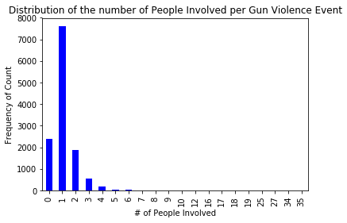

```python
#start of cluster modeling
#combine 2014-2017 data with 2018 data
frames = [dfloctag,dfloctag2018]
dfloctag2 = pd.concat(frames)

dfloctag2 = dfloctag2.loc[:,['tag','n_involved']]

dfloctag2 = dfloctag2[np.isfinite(dfloctag2['n_involved'])]
dfloctag2.n_involved.value_counts()

import matplotlib.pyplot as plt
import pandas

data = dfloctag2
fog, ax = plt.subplots()
data['n_involved'].value_counts().sort_index().plot(ax=ax, kind='bar', color = 'blue')
plt.title('Distribution of the number of People Involved per Gun Violence Event')
plt.xlabel('# of People Involved'), plt.ylabel('Frequency of Count')
```

```python
import pandas as pd
import numpy as np
from __future__ import print_function

df_imputed = dfloctag2.copy(deep=True)

#perform one-hot encoding of the categorical variable 'tag'
temp_df = pd.get_dummies(df_imputed.tag, prefix = 'tag')
df_imputed = pd.concat((df_imputed, temp_df), axis=1) #add the variables back into the dataframe

df_imputed_copy = df_imputed.copy(deep=True)

if 'tag' in df_imputed:
    del df_imputed['tag'] #get rid of the original category as it is now one-hot encoded and not needed

#normalize n_involved
y = df_imputed['n_involved']
df_imputed = (df_imputed - df_imputed.mean())/df_imputed.std()
df_imputed['n_involved'] = y
```

```
         tag  n_involved  tag_AUTO  tag_BANK  tag_CLUB  tag_DWELLING  \
0   DWELLING           0         0         0         0             1
1   DWELLING           0         0         0         0             1
2   DWELLING           1         0         0         0             1
3   DWELLING           1         0         0         0             1
6   DWELLING           1         0         0         0             1
7   DWELLING           7         0         0         0             1
8   DWELLING           0         0         0         0             1
9   DWELLING           0         0         0         0             1
10  DWELLING           0         0         0         0             1
11  DWELLING           1         0         0         0             1

    tag_EVENTCENTER  tag_NEIGHBORHOOD  tag_RESTAURANT  tag_ROADWAY  \
0                 0                 0               0            0
1                 0                 0               0            0
```

[output cut: 20 more lines]

```python
#baseline model performance
from sklearn.model_selection import StratifiedKFold, cross_val_score
from sklearn.ensemble import RandomForestClassifier

y = df_imputed['n_involved']
X = df_imputed[['tag_AUTO','tag_BANK','tag_CLUB','tag_DWELLING','tag_EVENTCENTER','tag_NEIGHBORHOOD','tag_RESTAURANT','tag_ROADWAY','tag_SCHOOL','tag_STORE']]

cv = StratifiedKFold(n_splits=10)

clf = RandomForestClassifier(n_estimators=150, random_state=1)
acc = cross_val_score(clf, X, y=y, cv = cv)

print("Average accuracy = ", acc.mean()*100, "+-", acc.std()*100)
```

```
Average accuracy =  57.04076498583726 +- 5.563393054389445
```

```python
#the jitter function to improve the graphical display of binomial data
def rand_jitter(arr):
    stdev = .01 * (max(arr)-min(arr))
    return arr + np.random.randn(len(arr)) * stdev

def jitter(x,y,s=20, c='b', marker = 'o', cmap = None, norm=None, vmin=None, vmax=None, alpha=None, linewidths = None, verts=None, hold = None, **kwargs):
     return plt.scatter(rand_jitter(x), rand_jitter(y), s=s, c=c, marker=marker, cmap=cmap, norm=norm, vmin=vmin, vmax=vmax, alpha=alpha, linewidths=linewidths, verts=verts, hold=hold, **kwargs)
```

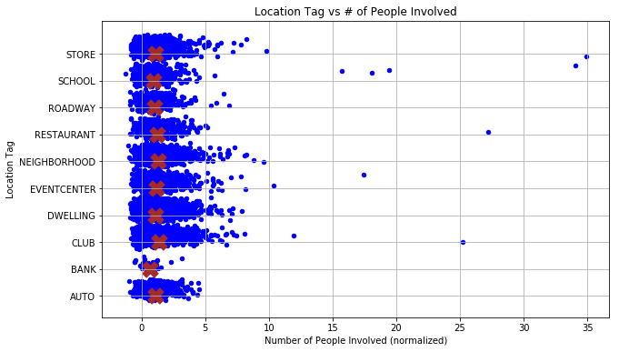

```python
df_imputed2 = df_imputed_copy.copy(deep = True)


AUTO = df_imputed2.loc[:,['n_involved','tag_AUTO']]
AUTO = AUTO[AUTO["tag_AUTO"] != 0]
AUTO['tag'] = 'AUTO'
AUTO['tagcode'] = 1
AUTO.columns = ['n_involved', 'tagvalue', 'tag','tagcode']

STORE = df_imputed2.loc[:,['n_involved','tag_STORE']]
STORE = STORE[STORE["tag_STORE"] != 0]
STORE['tag'] = 'STORE'
STORE['tagcode'] = 10
STORE.columns = ['n_involved', 'tagvalue', 'tag','tagcode']

SCHOOL = df_imputed2.loc[:,['n_involved','tag_SCHOOL']]
SCHOOL = SCHOOL[SCHOOL["tag_SCHOOL"] != 0]
SCHOOL['tag'] = 'SCHOOL'
SCHOOL['tagcode'] = 9
SCHOOL.columns = ['n_involved', 'tagvalue', 'tag','tagcode']

ROADWAY = df_imputed2.loc[:,['n_involved','tag_ROADWAY']]
ROADWAY = ROADWAY[ROADWAY["tag_ROADWAY"] != 0]
ROADWAY['tag'] = 'ROADWAY'
ROADWAY['tagcode'] = 8
ROADWAY.columns = ['n_involved', 'tagvalue', 'tag','tagcode']

RESTAURANT = df_imputed2.loc[:,['n_involved','tag_RESTAURANT']]
RESTAURANT = RESTAURANT[RESTAURANT["tag_RESTAURANT"] != 0]
RESTAURANT['tag'] = 'RESTAURANT'
RESTAURANT['tagcode'] = 7
RESTAURANT.columns = ['n_involved', 'tagvalue', 'tag','tagcode']

NEIGHBORHOOD = df_imputed2.loc[:,['n_involved','tag_NEIGHBORHOOD']]
NEIGHBORHOOD = NEIGHBORHOOD[NEIGHBORHOOD["tag_NEIGHBORHOOD"] != 0]
NEIGHBORHOOD['tag'] = 'NEIGHBORHOOD'
NEIGHBORHOOD['tagcode'] = 6
NEIGHBORHOOD.columns = ['n_involved', 'tagvalue', 'tag','tagcode']

EVENTCENTER = df_imputed2.loc[:,['n_involved','tag_EVENTCENTER']]
EVENTCENTER = EVENTCENTER[EVENTCENTER["tag_EVENTCENTER"] != 0]
EVENTCENTER['tag'] = 'EVENTCENTER'
EVENTCENTER['tagcode'] = 5
EVENTCENTER.columns = ['n_involved', 'tagvalue', 'tag','tagcode']

DWELLING = df_imputed2.loc[:,['n_involved','tag_DWELLING']]
DWELLING  = DWELLING[DWELLING["tag_DWELLING"] != 0]
DWELLING['tag'] = 'DWELLING'
DWELLING['tagcode'] = 4
DWELLING.columns = ['n_involved', 'tagvalue', 'tag','tagcode']

CLUB = df_imputed2.loc[:,['n_involved','tag_CLUB']]
CLUB  = CLUB[CLUB["tag_CLUB"] != 0]
CLUB['tag'] = 'CLUB'
CLUB['tagcode'] = 3
CLUB.columns = ['n_involved', 'tagvalue', 'tag','tagcode']

BANK = df_imputed2.loc[:,['n_involved','tag_BANK']]
BANK   = BANK[BANK["tag_BANK"] != 0]
BANK['tag'] = 'BANK'
BANK['tagcode'] = 2
BANK.columns = ['n_involved', 'tagvalue', 'tag','tagcode']

frames = [AUTO,BANK,CLUB,DWELLING, EVENTCENTER, NEIGHBORHOOD, RESTAURANT, ROADWAY, SCHOOL,STORE]
df_impall = pd.concat(frames)


X1 = df_impall[['tagcode', 'n_involved','tag']].values
tempX1 = DataFrame(X1)
tempX1.columns = ['tagcode', 'n_involved', 'tag']
tempX1['n_involved'] = tempX1.n_involved.astype(int)
cols_to_groupby = ['tag','tagcode']
X2 = tempX1.groupby(cols_to_groupby, as_index=False).mean()


plt.figure(figsize=(10, 6))

jitter(X1[:, 1], X1[:, 0] + np.random.random(X1[:, 1].shape)/2, s=20)
plt.scatter(X2.n_involved, X2.tagcode, marker = 'X', color='brown', s=300)
plt.xlabel('Number of People Involved (normalized)'), plt.ylabel('Location Tag')
plt.yticks(np.arange(1, 11, step=1), np.unique(X1[:,2]))
plt.grid()
plt.title('Location Tag vs # of People Involved')
plt.show()
```